# EDA with BaseR part 1

We will be covering Base R graphics for visualization.

These two questions can be helpful for making discoveries within your data:

1. What type of variation occurs within my variables?
2. What type of covariation occurs between my variables?

We will be using the Titanic survival prediction dataset that we will use for analysis of what sorts of people were likely to survive.

Add these libraries for dependencies

```r
library(magrittr)
library(dplyr)
```

Please add your path name to train.csv in the file argument.

```r
Titanic <- read.csv(file="train.csv", header=TRUE, sep=",")
```

Lets find out the names of the variables we have

```r
names(Titanic)
```

```
##  [1] "PassengerId" "Survived"    "Pclass"      "Name"        "Gender"
##  [6] "Age"         "SibSp"       "Parch"       "Ticket"      "Fare"
## [11] "Cabin"       "Embarked"
```

You can detail about the variables from here: https://www.kaggle.com/c/titanic/data

Lets find out more about our variable types

```r
str(Titanic)
```

```
## 'data.frame':    891 obs. of  12 variables:
##  $ PassengerId: int  1 2 3 4 5 6 7 8 9 10 ...
##  $ Survived   : int  0 1 1 1 0 0 0 0 1 1 ...
##  $ Pclass     : int  3 1 3 1 3 3 1 3 3 2 ...
##  $ Name       : Factor w/ 891 levels "Abbing, Mr. Anthony",..: 109 191 358 277 16 559 520 629 417 581 ...
##  $ Gender     : Factor w/ 2 levels "female","male": 2 1 1 1 2 2 2 2 1 1 ...
##  $ Age        : num  22 38 26 35 35 NA 54 2 27 14 ...
##  $ SibSp      : int  1 1 0 1 0 0 0 3 0 1 ...
##  $ Parch      : int  0 0 0 0 0 0 0 1 2 0 ...
##  $ Ticket     : Factor w/ 681 levels "110152","110413",..: 524 597 670 50 473 276 86 396 345 133 ...
##  $ Fare       : num  7.25 71.28 7.92 53.1 8.05 ...
##  $ Cabin      : Factor w/ 148 levels "","A10","A14",..: 1 83 1 57 1 1 131 1 1 1 ...
##  $ Embarked   : Factor w/ 4 levels "","C","Q","S": 4 2 4 4 4 3 4 4 4 2 ...
```

If we find out the summary of each of the variables, you will notice the Survived and Pclass are categorical by nature but are treated as numerical variables in Integer form

```r
summary(Titanic)
```

```
##   PassengerId       Survived          Pclass
##  Min.   :  1.0   Min.   :0.0000   Min.   :1.000
##  1st Qu.:223.5   1st Qu.:0.0000   1st Qu.:2.000
##  Median :446.0   Median :0.0000   Median :3.000
##  Mean   :446.0   Mean   :0.3838   Mean   :2.309
##  3rd Qu.:668.5   3rd Qu.:1.0000   3rd Qu.:3.000
##  Max.   :891.0   Max.   :1.0000   Max.   :3.000
##
##                                     Name        Gender         Age
##  Abbing, Mr. Anthony                  :  1   female:314   Min.   : 0.42
##  Abbott, Mr. Rossmore Edward          :  1   male  :577   1st Qu.:20.12
##  Abbott, Mrs. Stanton (Rosa Hunt)     :  1                Median :28.00
##  Abelson, Mr. Samuel                  :  1                Mean   :29.70
##  Abelson, Mrs. Samuel (Hannah Wizosky):  1                3rd Qu.:38.00
##  Adahl, Mr. Mauritz Nils Martin       :  1                Max.   :80.00
##  (Other)                              :885                NA's   :177
##      SibSp           Parch             Ticket         Fare
##  Min.   :0.000   Min.   :0.0000   1601    :  7   Min.   :  0.00
##  1st Qu.:0.000   1st Qu.:0.0000   347082  :  7   1st Qu.:  7.91
##  Median :0.000   Median :0.0000   CA. 2343:  7   Median : 14.45
##  Mean   :0.523   Mean   :0.3816   3101295 :  6   Mean   : 32.20
##  3rd Qu.:1.000   3rd Qu.:0.0000   347088  :  6   3rd Qu.: 31.00
##  Max.   :8.000   Max.   :6.0000   CA 2144 :  6   Max.   :512.33
##                                   (Other) :852
##          Cabin     Embarked
##             :687    :  2
##  B96 B98    :  4   C:168
##  C23 C25 C27:  4   Q: 77
##  G6         :  4   S:644
##  C22 C26    :  3
##  D          :  3
##  (Other)    :186
```

We can convert them using the factor function that will convert them into categorical values.

```r
Titanic$Pclass <- factor(Titanic$Pclass)
Titanic$Survived <- factor(Titanic$Survived)
Titanic$SibSp <- factor(Titanic$SibSp)
Titanic$Parch <- factor(Titanic$Parch)
```

Lets verify this using the summary function, they should give the count of the set of values instead of the central tendencies, Quartiles and IQR.

```r
summary(Titanic)
```

```
##   PassengerId    Survived Pclass
##  Min.   :  1.0   0:549    1:216
##  1st Qu.:223.5   1:342    2:184
##  Median :446.0            3:491
##  Mean   :446.0
##  3rd Qu.:668.5
##  Max.   :891.0
##
##                                     Name        Gender         Age
##  Abbing, Mr. Anthony                  :  1   female:314   Min.   : 0.42
##  Abbott, Mr. Rossmore Edward          :  1   male  :577   1st Qu.:20.12
##  Abbott, Mrs. Stanton (Rosa Hunt)     :  1                Median :28.00
##  Abelson, Mr. Samuel                  :  1                Mean   :29.70
##  Abelson, Mrs. Samuel (Hannah Wizosky):  1                3rd Qu.:38.00
##  Adahl, Mr. Mauritz Nils Martin       :  1                Max.   :80.00
##  (Other)                              :885                NA's   :177
##  SibSp   Parch        Ticket         Fare                Cabin
##  0:608   0:678   1601    :  7   Min.   :  0.00              :687
##  1:209   1:118   347082  :  7   1st Qu.:  7.91   B96 B98    :  4
##  2: 28   2: 80   CA. 2343:  7   Median : 14.45   C23 C25 C27:  4
##  3: 16   3:  5   3101295 :  6   Mean   : 32.20   G6         :  4
##  4: 18   4:  4   347088  :  6   3rd Qu.: 31.00   C22 C26    :  3
##  5:  5   5:  5   CA 2144 :  6   Max.   :512.33   D          :  3
##  8:  7   6:  1   (Other) :852                    (Other)    :186
##  Embarked
##   :  2
##  C:168
##  Q: 77
##  S:644
##
##
##
```

Let’s do barplotting of the variable Pclass. We are using the table function to create tabular results for this categorical variables.

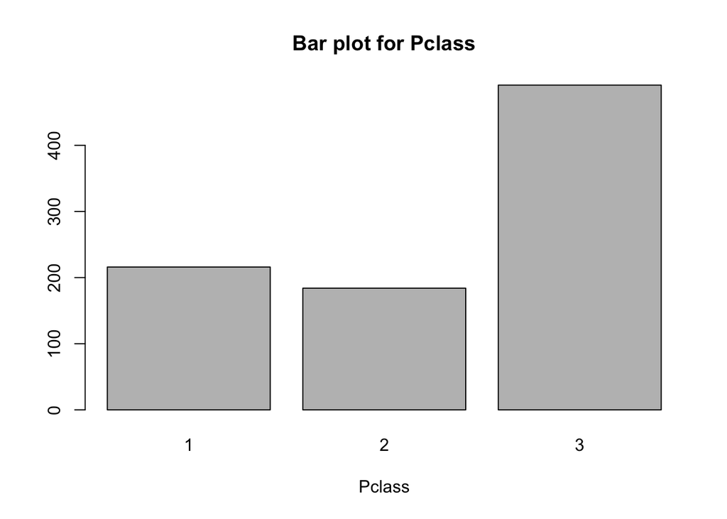

```r
barplot(table(Titanic$Pclass), main = "Bar plot for Pclass", xlab = "Pclass")
```

Let’s do barplotting of the variable Survived

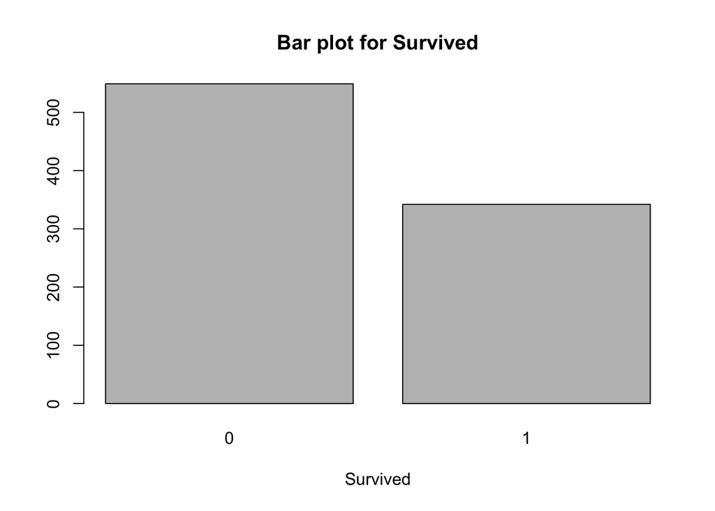

```r
barplot(table(Titanic$Survived), main ="Bar plot for Survived", xlab = "Survived")
```

The Survived is our target/predictor variable that will be used for supervised learning to predict if a passenger survives or not.

We will be comparing it with other variables to understand their relationships. We will start with cateogrical to categorical variable comparision (Bivariate Analysis).

Let’s first find out the proportion of passengers who survived from the training data set.

```r
Titanic %>% summarise(survived_FC = sum(Survived == 1)/ n())
```

```
##   survived_FC
## 1   0.3838384
```

Only 38% survived from the given data.

Compare Survived variable with Gender using cross tabulation.

```r
table(Titanic$Gender, Titanic$Survived)
```

```
##
##            0   1
##   female  81 233
##   male   468 109
```

Using plot function for visualising the contigency table for comparison of Gender and Survived

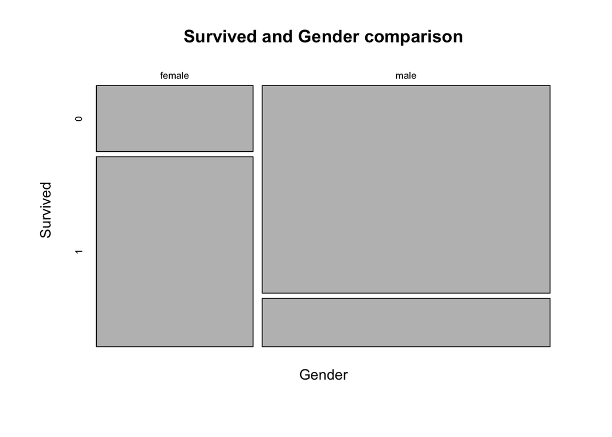

```r
plot(table(Titanic$Gender, Titanic$Survived), main = "Survived and Gender comparison", ylab = "Survived", xlab="Gender")
```

To get the proportion of females who survived

```r
Titanic %>% group_by(Survived) %>% summarise(femaleProportion = sum(Gender == "female") / sum(Titanic$Gender == "female"))
```

```
## # A tibble: 2 x 2
##   Survived femaleProportion
##   <fct>               <dbl>
## 1 0                   0.258
## 2 1                   0.742
```

The sum (Gender == “female”) is calculated with the context of the grouping by the ‘Survived’ variable, while the sum(Titanic$Gender == “female”) is from the total observation which should be equal to 314.

```r
sum(Titanic$Gender == "female")
```

```
## [1] 314
```

Compare Survived with the PClass using cross tabulation.

```r
table(Titanic$Pclass, Titanic$Survived)
```

```
##
##       0   1
##   1  80 136
##   2  97  87
##   3 372 119
```

Using plot function for visualising the contigency table for comparison of Pclass and Survived.

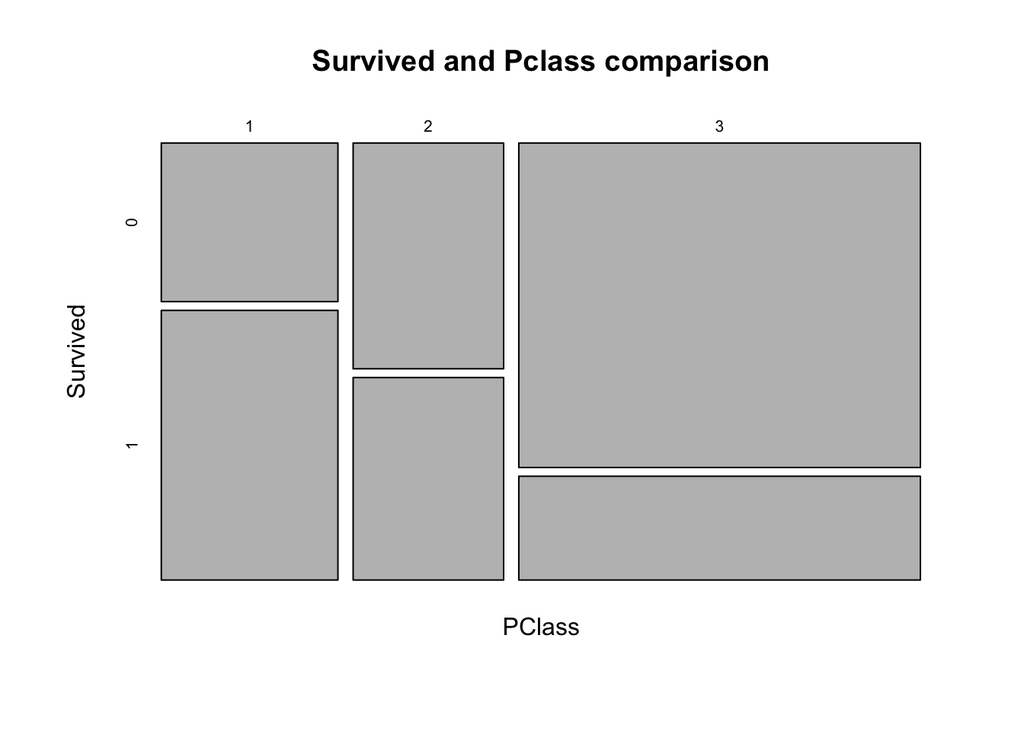

```r
plot(table(Titanic$Pclass, Titanic$Survived), main = "Survived and Pclass comparison", ylab = "Survived", xlab="PClass")
```

Get the proportion of high classed passengers who survived.

```r
Titanic %>% group_by(Survived) %>% summarise(highClassedProportion = sum(Pclass == 1) / sum(Titanic$Pclass == 1))
```

```
## # A tibble: 2 x 2
##   Survived highClassedProportion
##   <fct>                    <dbl>
## 1 0                        0.370
## 2 1                        0.630
```

Survived and Parch comparison using contingency table.

```r
table(Titanic$Survived, Titanic$Parch)
```

```
##
##       0   1   2   3   4   5   6
##   0 445  53  40   2   4   4   1
##   1 233  65  40   3   0   1   0
```

Using plot function for visualising the contigency table for comparison of Parch and Survived.

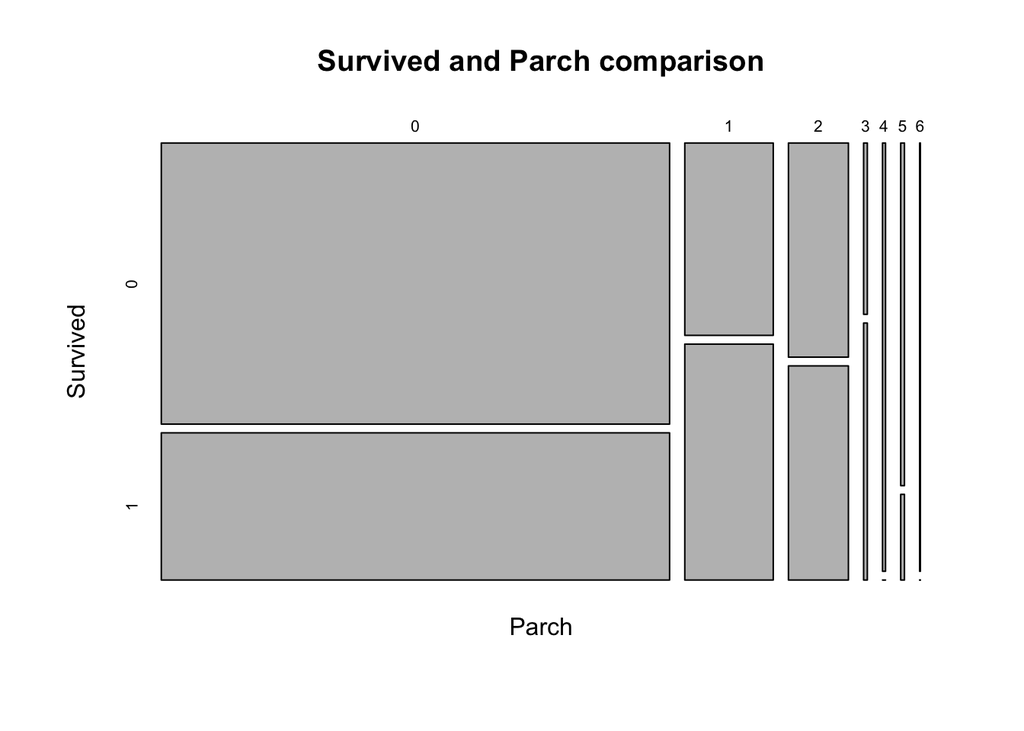

```r
plot(table(Titanic$Parch, Titanic$Survived), main = "Survived and Parch comparison", ylab = "Survived", xlab="Parch")
```

Get the proportion of passengers who had 0 parents/children

```r
Titanic %>% group_by(Survived) %>% summarise(NoParchProportion = sum(Parch == 0) / sum(Titanic$Parch == 0))
```

```
## # A tibble: 2 x 2
##   Survived NoParchProportion
##   <fct>                <dbl>
## 1 0                    0.656
## 2 1                    0.344
```